# Decision Tree

Emil Gil

2023-12-19

# Student : Emil Alfonso Gil

## Decision Trees, Bank Marketing dataset and Titanic

```r
library(rpart)

library(rpart.plot)

library(rattle)

library(titanic)
data("titanic_train")
head(titanic_train)
```

```
##   PassengerId Survived Pclass
## 1           1        0      3
## 2           2        1      1
## 3           3        1      3
## 4           4        1      1
## 5           5        0      3
## 6           6        0      3
##                                                  Name    Sex Age SibSp Parch
## 1                             Braund, Mr. Owen Harris   male  22     1     0
## 2 Cumings, Mrs. John Bradley (Florence Briggs Thayer) female  38     1     0
## 3                              Heikkinen, Miss. Laina female  26     0     0
## 4        Futrelle, Mrs. Jacques Heath (Lily May Peel) female  35     1     0
## 5                            Allen, Mr. William Henry   male  35     0     0
## 6                                    Moran, Mr. James   male  NA     0     0
##             Ticket    Fare Cabin Embarked
## 1        A/5 21171  7.2500              S
## 2         PC 17599 71.2833   C85        C
## 3 STON/O2. 3101282  7.9250              S
## 4           113803 53.1000  C123        S
## 5           373450  8.0500              S
## 6           330877  8.4583              Q
```

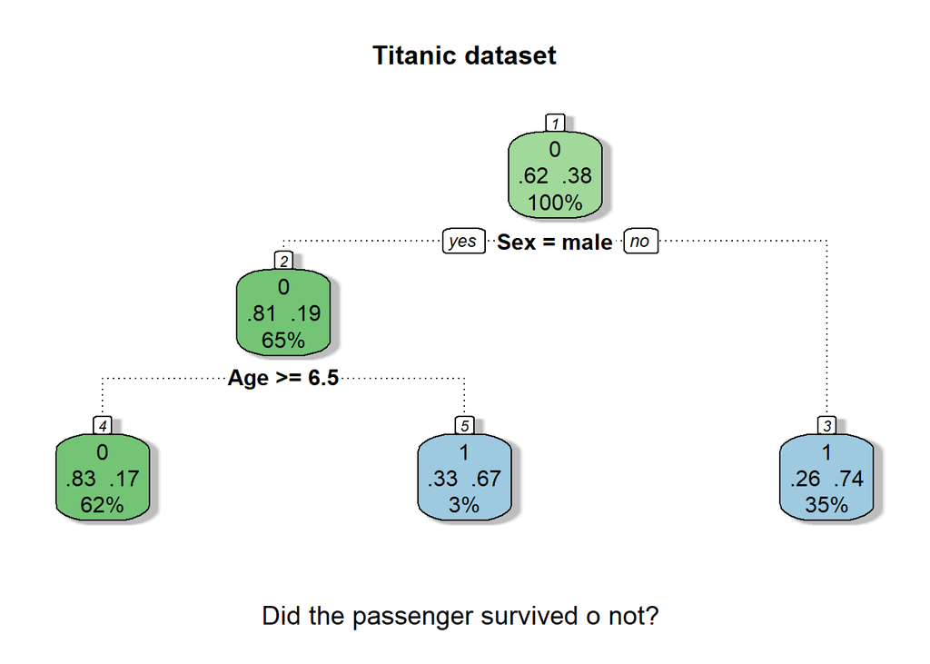

```r
arbol <- rpart(
  formula = Survived ~ Sex + Age,
  data = titanic_train,
  method = 'class'
)
fancyRpartPlot(arbol, main = "Titanic dataset", sub = "Did the passenger survived o not?")
```

Bank Marketing Dataset: This is the classic marketing bank dataset uploaded originally in the UCI Machine Learning Repository. The dataset gives you information about a marketing campaign of a financial institution in which you will have to analyze in order to find ways to look for future strategies in order to improve future marketing campaigns for the bank.

```r
bank <- read.csv("bank.csv")
str(bank)
```

```
## 'data.frame':    11162 obs. of  17 variables:
##  $ age      : int  59 56 41 55 54 42 56 60 37 28 ...
##  $ job      : chr  "admin." "admin." "technician" "services" ...
##  $ marital  : chr  "married" "married" "married" "married" ...
##  $ education: chr  "secondary" "secondary" "secondary" "secondary" ...
##  $ default  : chr  "no" "no" "no" "no" ...
##  $ balance  : int  2343 45 1270 2476 184 0 830 545 1 5090 ...
##  $ housing  : chr  "yes" "no" "yes" "yes" ...
##  $ loan     : chr  "no" "no" "no" "no" ...
##  $ contact  : chr  "unknown" "unknown" "unknown" "unknown" ...
##  $ day      : int  5 5 5 5 5 5 6 6 6 6 ...
##  $ month    : chr  "may" "may" "may" "may" ...
##  $ duration : int  1042 1467 1389 579 673 562 1201 1030 608 1297 ...
##  $ campaign : int  1 1 1 1 2 2 1 1 1 3 ...
##  $ pdays    : int  -1 -1 -1 -1 -1 -1 -1 -1 -1 -1 ...
##  $ previous : int  0 0 0 0 0 0 0 0 0 0 ...
##  $ poutcome : chr  "unknown" "unknown" "unknown" "unknown" ...
##  $ deposit  : chr  "yes" "yes" "yes" "yes" ...
```

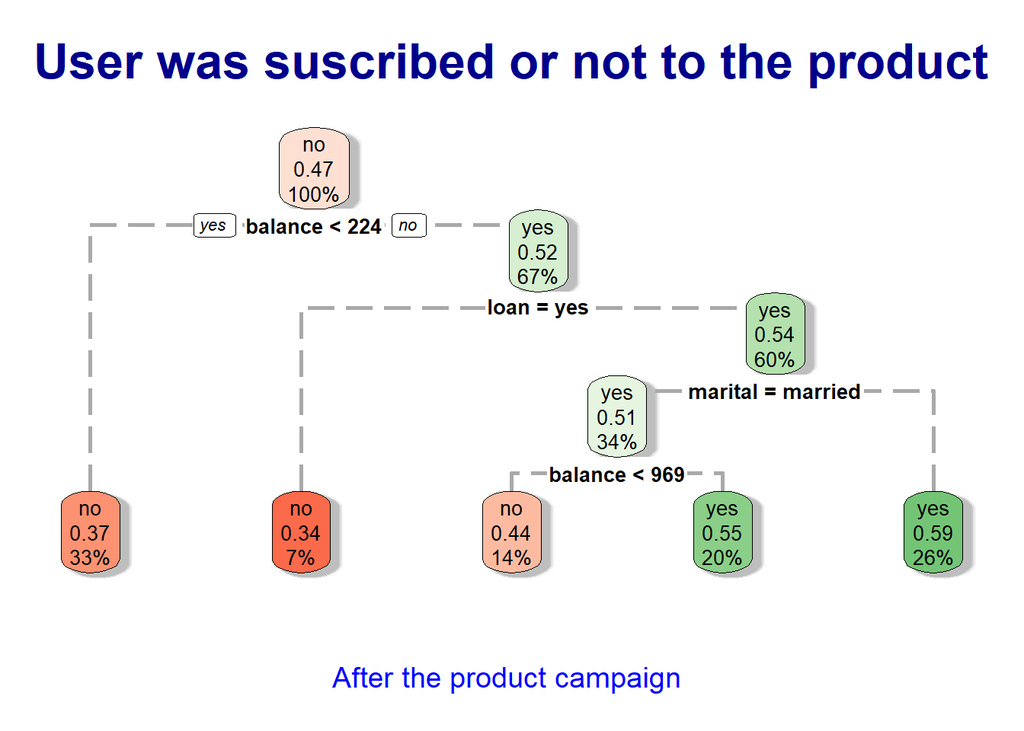

```r
arbol <- rpart(
  formula = deposit ~ marital + loan + balance,
  data = bank,
  method = 'class'
)

rpart.plot(arbol,
           box.palette = "RdGn",
           main = "User was suscribed or not to the product",
           sub = "After the product campaign",
           branch.col = "darkgray",
           branch.lty = 5,
           branch.lwd = 3,
           cex = .85,
           shadow.col = "gray",
           cex.main = 2,
           col.main = "darkblue",
           col.sub = "blue")
```

## Analisis del arbol de decision / Decision tree analysis

Este arbol de decision busca clasificar en base a la variable Deposit, esta representa si el cliente se ha suscrito o no al producto o servicio después de una campaña de marketing.

Se utilizan varios parametros para determinar esto como lo son: edad, trabajo, educacion, estado civil, tipo de telefono, duracion de la llamada, etc.

Sin embargo se estan utilizando los parametros de Marital, Loan y Balance para representar el arbol de desicion.

Marital (Estado Civil): Esta variable indica el estado civil de los clientes. Puede tener categorías como “soltero”, “casado” o “divorciado”. El estado civil puede influir en las decisiones financieras y en la receptividad a productos o servicios ofrecidos en la campaña.

Loan (Prestamo): Esta variable es binaria y generalmente representa si un cliente tiene un préstamo personal o no. Puede tener dos valores: “yes” (sí) o “no” (no). La presencia de un préstamo puede ser un factor importante al evaluar la capacidad de un cliente para suscribirse a nuevos productos o servicios.

Balance (Saldo): Esta variable generalmente se refiere al saldo de la cuenta bancaria del cliente. Indica cuánto dinero tiene el cliente en su cuenta en un momento dado. El saldo bancario puede ser un indicador crucial de la capacidad financiera de un cliente y, por lo tanto, puede influir en su disposición para participar en la campaña.

This decision tree aims to classify based on the “Deposit” variable, which represents whether the customer has subscribed or not to the product or service after a marketing campaign.

Several parameters are used to determine this, such as age, occupation, education, marital status, type of phone, call duration, etc.

However, the “Marital,” “Loan,” and “Balance” parameters are being used to represent the decision tree.

Marital: This variable indicates the marital status of the customers. It can have categories such as “single,” “married,” or “divorced.” Marital status can influence financial decisions and receptiveness to products or services offered in the campaign.

Loan: This variable is binary and generally represents whether a customer has a personal loan or not. It can have two values: “yes” or “no.” The presence of a loan can be an important factor when evaluating a customer’s ability to subscribe to new products or services.

Balance: This variable generally refers to the balance of the customer’s bank account. It indicates how much money the customer has in their account at a given time. The bank balance can be a crucial indicator of a customer’s financial capacity and, therefore, can influence their willingness to participate in the campaign.

## Analisis / Analysis

De esos que no tenian prestamo, un 26% no estaba casado se suscribieron, en cambio, un 34% si estaba casado y de esos casados los que tenian un balance menor a 969 (14%) no se suscribieron, en cambio el 20% restante que si tenia el balance mayor a 969, si se suscribio.

En conclusion podemos observar que el mayor porcentaje de las personas que se suscribieron tienen las caracteristicas de un balance mayor a 224, no tienen prestamos y no estan casados, es decir, estan solteros o divorciados.

Por otro lado el mayor porcentaje de los que no se suscribieron simplemente no estaban en buena situacion economica, es decir, tenian un balance menor a 224. Lo mismo se puede observar con el 7% que tenia el balance mayor a 224 pero era por prestamo, por lo que tampoco se suscribieron.

In conclusion, we can observe that the highest percentage of subscribers has the characteristic of a balance greater than 224, no loans, and being unmarried or divorced. On the other hand, the highest percentage of non-subscribers simply did not have a good financial situation, meaning they had a balance less than 224. The same can be observed with the 7% who had a balance greater than 224 but it was due to a loan, so they also did not subscribe.